# Ende Possession

Kate Lindsey

2023-04-24

## Data mining

The raw data comes from a .txt file called phrases.txt, which was provided by Jack Rabinovitch. The data was scraped from an April 2023 version of the Ende FLEx corpus.

```r
library(readr)
phrases <- read_delim("C:/Users/profk/Downloads/phrases.txt",
     delim = "\t", escape_double = FALSE,
     trim_ws = TRUE)
```

This dataframe has 37,772 phrases.

To focus on possession terms, I reduced the data to only the rows that have “.poss” or “sg.abl” in the words_gls column.

```r
phrases$words_gls <- gsub("sg.abl", "sg.pst.poss", phrases$words_gls)

df_poss <- subset(phrases, grepl("poss", words_gls))
```

The new dataframe has 7,560 phrases.

To tidy up the dataframe, I will create a new column for the phrase (phrase_txt), which is words_txt without the commas. I will rename the gls column to phrase_tr, the words_txt to word_txt and the words_gl to word_tr and I will remove all columns except for word_tr, word_txt, phrase_tr, and phrase_txt.

```r
library(dplyr)
tidy_poss <- df_poss %>% mutate(phrase_txt = gsub(",", " ", words_txt))
tidy_poss$phrase_txt <- gsub("  ", " ", tidy_poss$phrase_txt)
tidy_poss$phrase_txt <- gsub("  ", " ", tidy_poss$phrase_txt)
tidy_poss$phrase_txt <- gsub("  ", " ", tidy_poss$phrase_txt)
tidy_poss <- tidy_poss %>% rename(phrase_tr = gls, word_txt = words_txt, word_tr = words_gls)
tidy_poss <- select(tidy_poss, word_txt, word_tr, phrase_txt, phrase_tr)
```

Now, we will reorganize the dataframe so that each row represents one word.

```r
library(tidyr)
library(stringr)

tidy_poss$word_tr <- gsub("correct, true, right", "correct", tidy_poss$word_tr) #this translation was giving us trouble

tidy_poss[265, "word_tr"] <- paste(tidy_poss[265, "word_tr"], " ,")
tidy_poss[422, "word_tr"] <- paste(tidy_poss[422, "word_tr"], " ,")
tidy_poss[1225, "word_tr"] <- paste(tidy_poss[1225, "word_tr"], " ,")
tidy_poss[1309, "word_tr"] <- paste(tidy_poss[1309, "word_tr"], " ,")
tidy_poss[3378, "word_tr"] <- paste(tidy_poss[3378, "word_tr"], " ,")
tidy_poss[3733, "word_tr"] <- paste(tidy_poss[3733, "word_tr"], " ,")
tidy_poss[4198, "word_tr"] <- paste(tidy_poss[4198, "word_tr"], " ,")
tidy_poss[4619, "word_tr"] <- paste(tidy_poss[4619, "word_tr"], " ,")
tidy_poss[4652, "word_tr"] <- paste(tidy_poss[4652, "word_tr"], " ,")
tidy_poss[5045, "word_tr"] <- paste(tidy_poss[5045, "word_tr"], " ,")
tidy_poss[5207, "word_tr"] <- paste(tidy_poss[5207, "word_tr"], " ,")
tidy_poss[5391, "word_tr"] <- paste(tidy_poss[5391, "word_tr"], " ,")
tidy_poss[5650, "word_tr"] <- paste(tidy_poss[5650, "word_tr"], " ,")
tidy_poss[5989, "word_tr"] <- paste(tidy_poss[5989, "word_tr"], " ,")
tidy_poss[5990, "word_tr"] <- paste(tidy_poss[5990, "word_tr"], " ,")
tidy_poss[5991, "word_tr"] <- paste(tidy_poss[5991, "word_tr"], " ,")
tidy_poss[5992, "word_tr"] <- paste(tidy_poss[5992, "word_tr"], " ,")
tidy_poss[6276, "word_tr"] <- paste(tidy_poss[6276, "word_tr"], " ,")
tidy_poss[6286, "word_tr"] <- paste(tidy_poss[6286, "word_tr"], " ,")
tidy_poss[6333, "word_tr"] <- paste(tidy_poss[6333, "word_tr"], " ,")
tidy_poss[6418, "word_tr"] <- paste(tidy_poss[6418, "word_tr"], " ,")
tidy_poss[6509, "word_tr"] <- paste(tidy_poss[6509, "word_tr"], " ,")
tidy_poss[6519, "word_tr"] <- paste(tidy_poss[6519, "word_tr"], " ,")
tidy_poss[6672, "word_tr"] <- paste(tidy_poss[6672, "word_tr"], " ,")
tidy_poss[6802, "word_tr"] <- paste(tidy_poss[6802, "word_tr"], " ,")
tidy_poss[6913, "word_tr"] <- paste(tidy_poss[6913, "word_tr"], " ,")
tidy_poss[6939, "word_tr"] <- paste(tidy_poss[6939, "word_tr"], " ,")
tidy_poss[6962, "word_tr"] <- paste(tidy_poss[6962, "word_tr"], " ,")
tidy_poss[7030, "word_tr"] <- paste(tidy_poss[7030, "word_tr"], " ,")
tidy_poss[7032, "word_tr"] <- paste(tidy_poss[7032, "word_tr"], " ,")
tidy_poss[7043, "word_tr"] <- paste(tidy_poss[7043, "word_tr"], " ,")
tidy_poss[7110, "word_tr"] <- paste(tidy_poss[7110, "word_tr"], " ,")
tidy_poss[7276, "word_tr"] <- paste(tidy_poss[7276, "word_tr"], " ,")
tidy_poss[7348, "word_tr"] <- paste(tidy_poss[7348, "word_tr"], " ,")


tidy_poss <- tidy_poss %>% separate_rows(word_txt, word_tr, sep = ", ")
tidy_poss <- tidy_poss %>% mutate_all(str_trim)
```

Now, we will add four columns, two for previous word and previous word translation and two for following word and following word translation.

```r
tidy_poss$prev_word_txt <- lag(tidy_poss$word_txt)
tidy_poss$prev_word_tr <- lag(tidy_poss$word_tr)
tidy_poss$next_word_txt <- lead(tidy_poss$word_txt)
tidy_poss$next_word_tr <- lead(tidy_poss$word_tr)
```

Now, we will clean up the rows once more, only retaining the words with “poss” in the word_tr column and removing capitalization.

```r
tidy_poss <- subset(tidy_poss, grepl("poss", word_tr))
tidy_poss$word_txt <- tolower(tidy_poss$word_txt)
tidy_poss$prev_word_txt <- tolower(tidy_poss$prev_word_txt)
tidy_poss$next_word_txt <- tolower(tidy_poss$next_word_txt)
```

I noticed that possession words followed by certain words are not marking possession in the sense we are interested in, so I will remove all the rows that have these words in the next_word_txt column.

```r
tidy_poss <- tidy_poss[tidy_poss$next_word_txt != "peyang", ]
tidy_poss <- tidy_poss[tidy_poss$next_word_txt != "pate", ]
tidy_poss <- tidy_poss[tidy_poss$next_word_txt != "patme", ]
tidy_poss <- tidy_poss[tidy_poss$next_word_txt != "pallall", ]
tidy_poss <- tidy_poss[tidy_poss$next_word_txt != "moko", ]
tidy_poss <- tidy_poss[tidy_poss$next_word_txt != "umllang", ]
tidy_poss <- tidy_poss[tidy_poss$next_word_txt != "kame", ]
```

This reduced the number of observations from 10546 to 9547.

## Data visualization

Here is a list of all the possession words identified in the dataset, along with their frequencies.

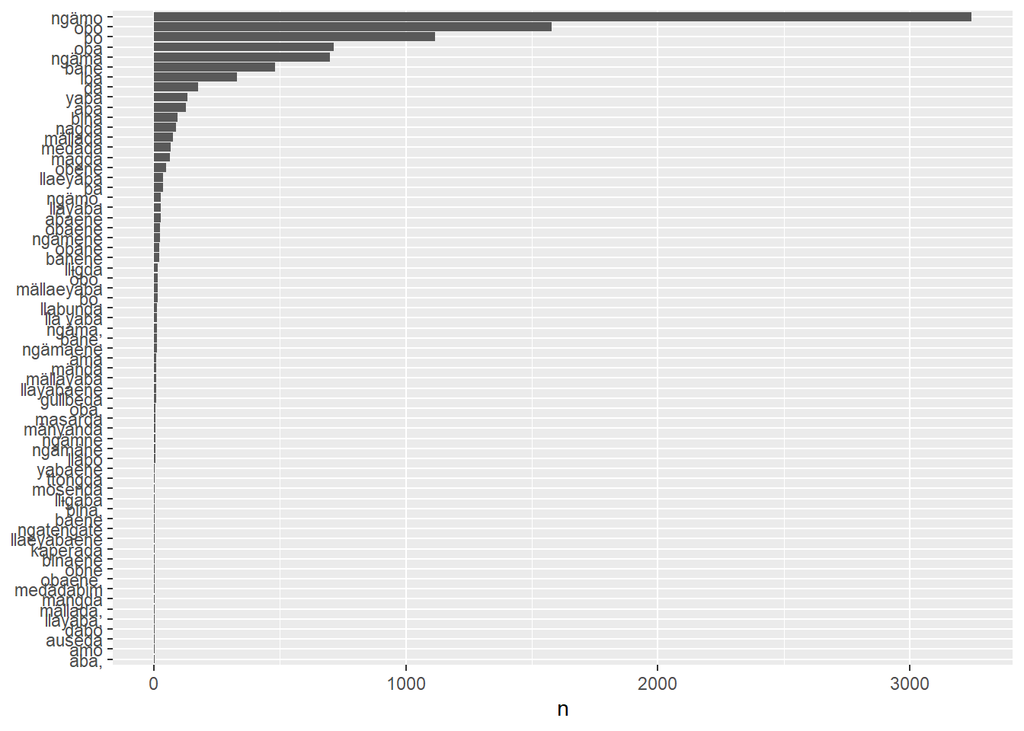

```r
library(ggplot2)

tidy_poss %>%
     count(word_txt, sort = TRUE) %>%
     filter(n > 1) %>%
     mutate(word_txt = reorder(word_txt, n)) %>%
     ggplot(aes(n, word_txt)) +
     geom_col() +
     labs(y = NULL)
```

Here is a list of all the glosses of the possession words identified in the dataset, along with their frequencies.

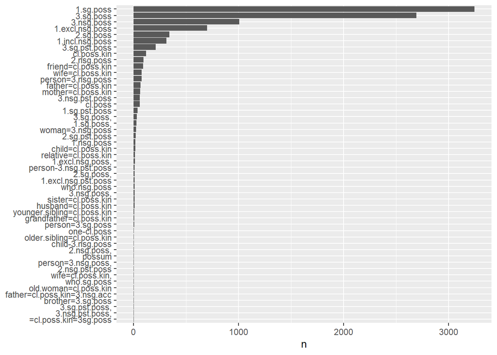

```r
tidy_poss %>%
     count(word_tr, sort = TRUE) %>%
     filter(n > 1) %>%
     mutate(word_tr = reorder(word_tr, n)) %>%
     ggplot(aes(n, word_tr)) +
     geom_col() +
     labs(y = NULL)
```

Here is a word cloud of all the words in the next_word_txt, which we may assume to be the possessees in this dataset.

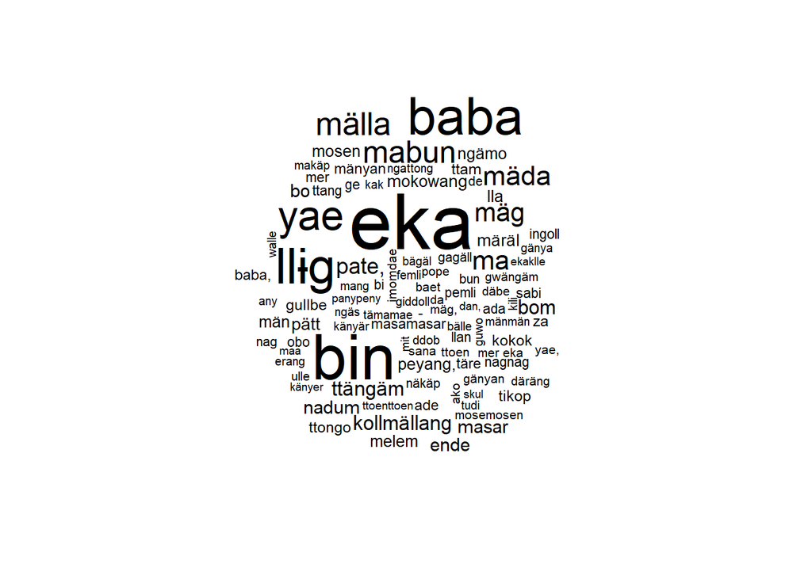

```r
library(wordcloud)
tidy_poss %>%
  count(next_word_txt) %>%
  with(wordcloud(next_word_txt, n, max.words = 100))
```

Here is a word cloud of all the words in the next_word_tr, which we may assume to be the possessees in this dataset.

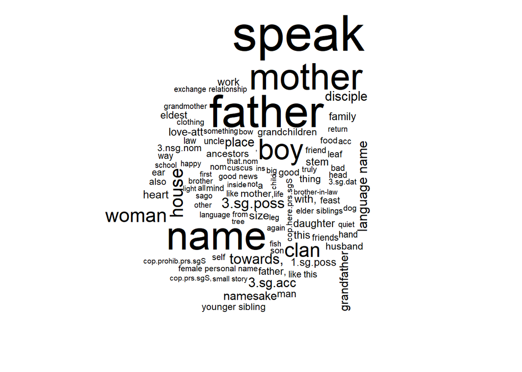

```r
library(wordcloud)

tidy_poss %>%
  count(next_word_tr) %>%
  with(wordcloud(next_word_tr, n, max.words = 100))
```

We can do a little more clean-up here, removing the words ngatengate ‘possum’ and ai ‘possible’.

```r
tidy_poss <- tidy_poss %>%
  filter(!grepl("possum|possible", word_tr))
```

## Data coding

We can now start to code our dataset for relevant properties.

First, we can clean up our list or possession words by making a new column called possession type.

```r
tidy_poss <- tidy_poss %>%
  mutate(poss_type = if_else(!str_detect(word_tr, "cl\\.poss\\.kin"), paste("da", next_word_txt, sep = " "), "da"), poss_type = if_else(!str_detect(word_tr, "cl\\.p"), word_txt, poss_type))

tidy_poss <- tidy_poss %>%
  mutate(poss_type = gsub("\\b\\w+aba\\b", "aba", poss_type))
tidy_poss$poss_type <- ifelse(tidy_poss$poss_type == "lla (y)aba", "aba", tidy_poss$poss_type)

tidy_poss$poss_type <- gsub("lla aba", "aba", tidy_poss$poss_type)

tidy_poss$poss_type <- gsub("abaene|yabaene|llayabaene|llaeyabaene|\\bbaene", "abaene", tidy_poss$poss_type)

tidy_poss$poss_type <- gsub("llabo", "bo", tidy_poss$poss_type)

tidy_poss$poss_type <- gsub("obäne|obne", "obene", tidy_poss$poss_type)

tidy_poss$poss_type <- gsub("ngämne|ngämäne", "ngämene", tidy_poss$poss_type)

tidy_poss$poss_type <- gsub("mangda", "da", tidy_poss$poss_type)


tidy_poss$poss_type <- ifelse(tidy_poss$word_tr == "2.sg.poss", "bäne (2)", tidy_poss$poss_type)


tidy_poss$poss_type <- trimws(tidy_poss$poss_type)
tidy_poss$poss_type <- gsub(",", "", tidy_poss$poss_type)
```

Now, we can look at the frequencies of possession type.

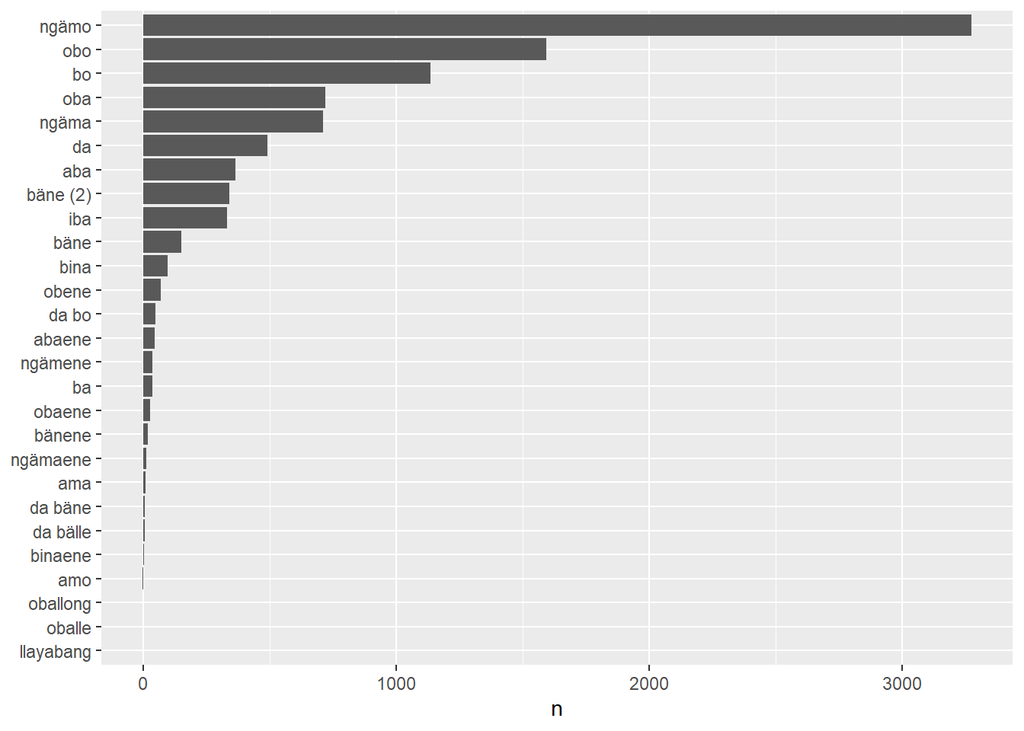

```r
tidy_poss %>%
     count(poss_type, sort = TRUE) %>%
     filter(n > 0) %>%
     mutate(poss_type = reorder(poss_type, n)) %>%
     ggplot(aes(n, poss_type)) +
     geom_col() +
     labs(y = NULL)
```

Next, we can add a column that splits the data between pronominal and non-pronominal possession types.

```r
tidy_poss$pronominal <- ifelse(grepl("[1-3]", tidy_poss$word_tr), "yes", "no")
table(tidy_poss$pronominal)
```

```
##
##   no  yes
##  559 8984
```

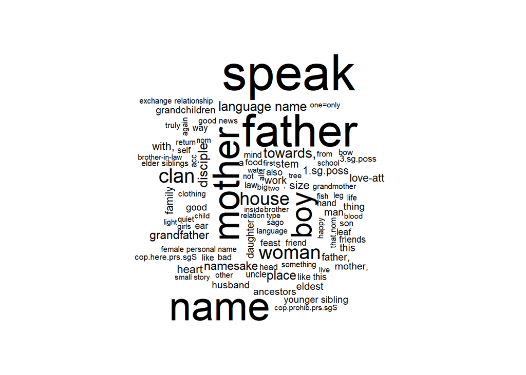

```r
# Wordcloud for pronominal = "yes"
tidy_poss %>%
  filter(pronominal == "yes") %>%
  count(next_word_tr) %>%
  with(wordcloud(next_word_tr, n, max.words = 100))
```

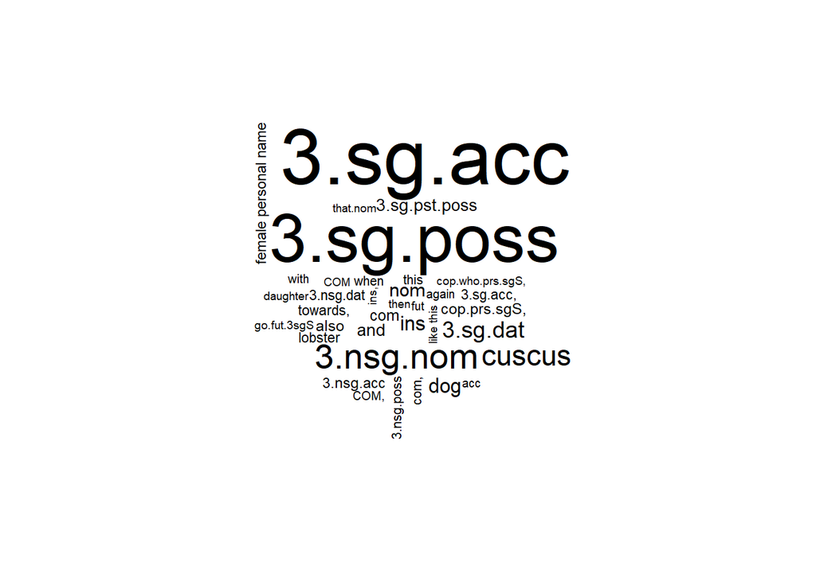

```r
# Wordcloud for pronominal = "no"
tidy_poss %>%
  filter(pronominal == "no") %>%
  count(next_word_tr) %>%
  with(wordcloud(next_word_tr, n, max.words = 100))
```

We learn that the data is overwhelmingly pronominal.

How about genitive and ablative for the pronominal forms?

```r
tidy_poss$ablative <- ifelse(tidy_poss$pronominal == "yes" & grepl("pst", tidy_poss$word_tr), "yes",
                     ifelse(tidy_poss$pronominal == "yes" & !grepl("pst", tidy_poss$word_tr), "no", NA))

table(tidy_poss$ablative)
```

```
##
##   no  yes
## 8627  357
```

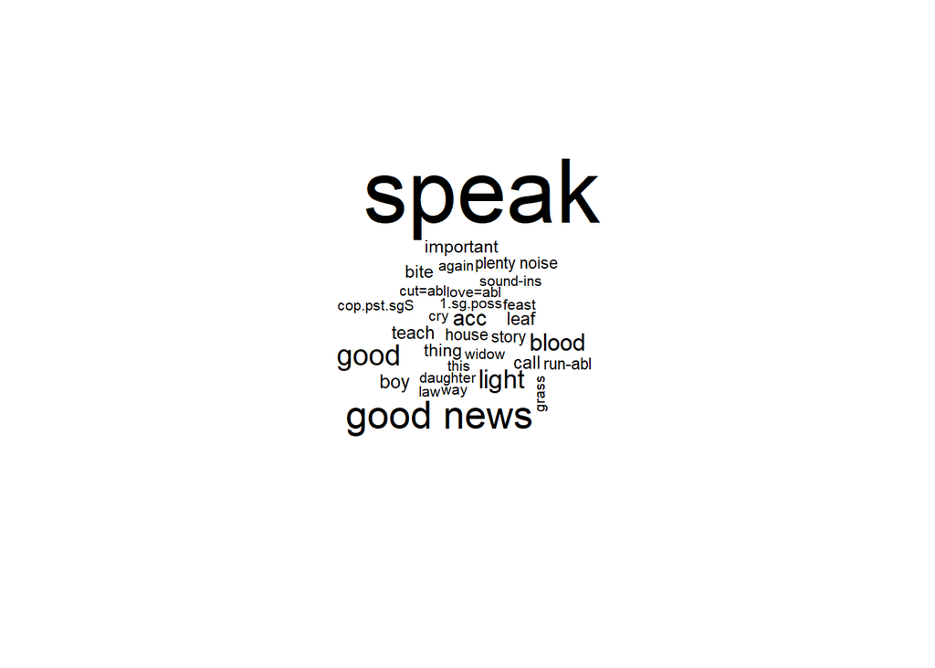

```r
# Wordcloud for ablative = "yes"
tidy_poss %>%
  filter(ablative == "yes") %>%
  count(next_word_tr) %>%
  with(wordcloud(next_word_tr, n, max.words = 100))
```

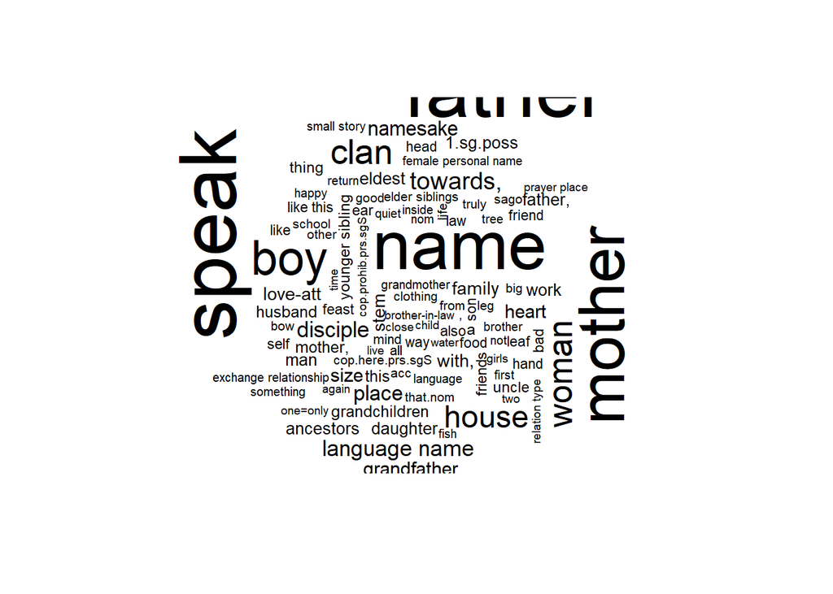

```r
# Wordcloud for ablative = "no"
tidy_poss %>%
  filter(ablative == "no") %>%
  count(next_word_tr) %>%
  with(wordcloud(next_word_tr, n, max.words = 100))
```

The genitive is also much more common than the ablative.

A reminder to save all my dataframes to be pushed to GitHub.

```r
write.csv(phrases, "phrases.csv", row.names = FALSE)
write.csv(df_poss, "df_poss.csv", row.names = FALSE)
write.csv(tidy_poss, "tidy_poss.csv", row.names = FALSE)
```